# Tidyverse BMI 704 Laboratory

Chirag Patel and Chirag Lakhani

1/21/2018

# Data Description

These data are from the National Health and Nutrition Examination Survey (NHANES), a non-institutionalized sampling of the United States: https://www.cdc.gov/nchs/nhanes/index.htm

In this lab we will explore phenotypes (P) of the metabolic syndrome, a risk factor for type 2 diabetes and heart disease.

# Data catalog

```r
DT::datatable(VarDescription)
```

|  | var | var_desc |
| --- | --- | --- |
| 100 | LBXGLU | Glucose, plasma (mg/dL) |
| 115 | LBXTR | Triglyceride (mg/dL) |
| 117 | LBDLDL | LDL-cholesterol (mg/dL) |
| 580 | LBXGLU | Fasting Glucose (mg/dL) |
| 744 | LBDHDL | HDL-cholesterol (mg/dL) |
| 2361 | BMXBMI | Body Mass Index (kg/m**2) |
| 2411 | MSYS | mean systolic |
| 2415 | MDIS | mean diastolic |
| 2754 | LBDHDL | Direct HDL-Cholesterol (mg/dL) |
| 1 | RIDAGEYR | Age in Years |

[output cut: 7 more lines]

# Data Manipulation

- create a new variable called *gender* (using the *RIAGENDR* column) with values and append to the dataframe **nhData**
  - M - males
  - F - females
- create a new variable called *ethnicity* (using the *RIDRETH1* column) with the following values and append to the dataframe **nhData**
  - H - Mexican American or Other Hispanic
  - W - White
  - B - Black
  - O - Other
- create a new variable called *age_group* (using the *RIDAGEYR* column) with the following values and append to the dataframe **nhData**
  - [0-18)
  - [18-30)
  - [30-60)
  - [60+)
- create a new variable called *obesity* (using the *BMXBMI* column) with the following values and append to the dataframe **nhData**
  - normal - if BMXBMI < 30
  - obese - if BMXBMI >= 30
- create a new variable called *diabetes* (using the *LBXGLU* column) with the following values and append to the dataframe **nhData**
  - normal - if LBXGLU < 126.0
  - diabetic - if LBXGLU >= 126.0

```r
nhData <- nhData %>% mutate(gender = case_when(RIAGENDR == '1' ~ 'M',
                                               RIAGENDR == '2' ~ 'F' ))


nhData <- nhData %>% mutate(ethnicity = case_when(RIDRETH1 == '1' | RIDRETH1 == '2'  ~ 'H',
                                                  RIDRETH1 == '3' ~ 'W',
                                                  RIDRETH1 == '4' ~ 'B',
                                                  RIDRETH1 == '5' ~ 'O',))



nhData <- nhData %>% mutate(age_group = case_when(RIDAGEYR >= 0 & RIDAGEYR < 18   ~ '[0,18)',
                                                  RIDAGEYR >= 18 & RIDAGEYR < 30   ~ '[18,30)',
                                                  RIDAGEYR >= 30 & RIDAGEYR < 60   ~ '[30,60)',
                                                  RIDAGEYR >= 60   ~ '[60+)',))



nhData <- nhData %>% mutate(obesity = case_when(BMXBMI < 30   ~ 'normal',
                                                BMXBMI >= 30   ~ 'obese'))


nhData <- nhData %>% mutate(diabetes = case_when(LBXGLU < 126.0   ~ 'normal',
                                                LBXGLU >= 126.0   ~ 'diabetic'))
```

# Data Exploration with dplyr

### Find the following counts

- Number of individuals by gender
- Number of individuals by ethnicity
- Number of individuals by age group
- Number of individuals by gender and ethnicity (order by ethnicity and then gender)

```r
nhData %>% group_by(gender) %>% summarise(numIndividuals=n())
```

```
## # A tibble: 2 x 2
##   gender numIndividuals
##    <chr>          <int>
## 1      F           8916
## 2      M           8942
```

```r
nhData %>% group_by(ethnicity) %>% summarise(numIndividuals=n())
```

```
## # A tibble: 4 x 2
##   ethnicity numIndividuals
##       <chr>          <int>
## 1         B           3912
## 2         H           5106
## 3         O           1080
## 4         W           7760
```

```r
nhData %>% group_by(age_group) %>% summarise(numIndividuals=n())
```

```
## # A tibble: 4 x 2
##   age_group numIndividuals
##       <chr>          <int>
## 1    [0,18)           3353
## 2   [18,30)           3635
## 3   [30,60)           6669
## 4     [60+)           4201
```

```r
nhData %>% group_by(gender,ethnicity) %>% summarise(numIndividuals=n()) %>% arrange(ethnicity,gender)
```

```
## # A tibble: 8 x 3
## # Groups:   gender [2]
##   gender ethnicity numIndividuals
##    <chr>     <chr>          <int>
## 1      F         B           1923
## 2      M         B           1989
## 3      F         H           2553
## 4      M         H           2553
## 5      F         O            544
## 6      M         O            536
## 7      F         W           3896
## 8      M         W           3864
```

### More practice with dplyr

- Create a dataframe called **bmi_ldl_df_age_gender** which contains only BMI, LDL, age group, and gender
- Using **bmi_ldl_df_age_gender** create a new dataset called **bmi_ldl_age_female** which only contains females
- Using the data frame **bmi_ldl_age_female** estimate the mean bmi and ldl level for each age group

```r
bmi_ldl_df_age_gender <- nhData %>% select(BMXBMI,LBDLDL,age_group,gender)

bmi_ldl_df_age_female <- bmi_ldl_df_age_gender %>% filter(gender =='F')

bmi_ldl_df_age_female %>% group_by(age_group) %>% summarise(avgLDL=mean(LBDLDL), avgBMI=mean(BMXBMI))
```

```
## # A tibble: 4 x 3
##   age_group   avgLDL   avgBMI
##       <chr>    <dbl>    <dbl>
## 1    [0,18)  89.8716 23.63529
## 2   [18,30) 103.8287 27.17466
## 3   [30,60) 118.4827 29.44171
## 4     [60+) 121.9855 28.99606
```

# Plotting with ggplot2

- What is the distribution of age in the population? Use 60 bins instead of default of 30.

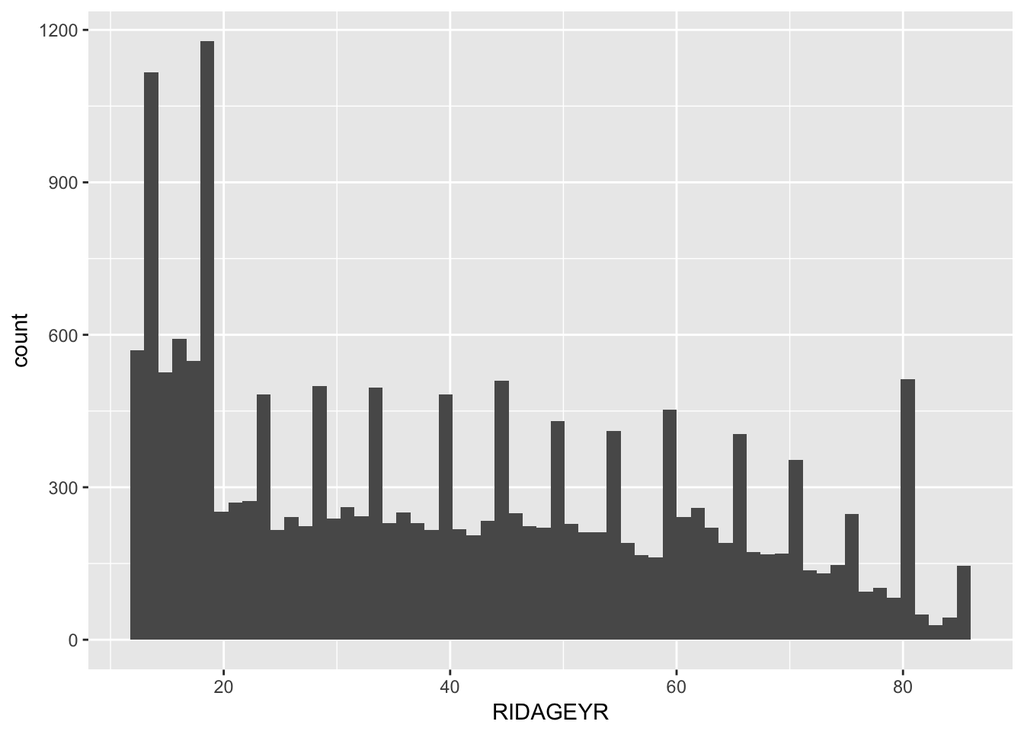

```r
ggplot(nhData,aes(RIDAGEYR)) + geom_histogram(bins=60)
```

Create boxplots of BMI, systolic blood pressure and LDL by gender (using the **nhData** dataframe) (give each gender a different color)

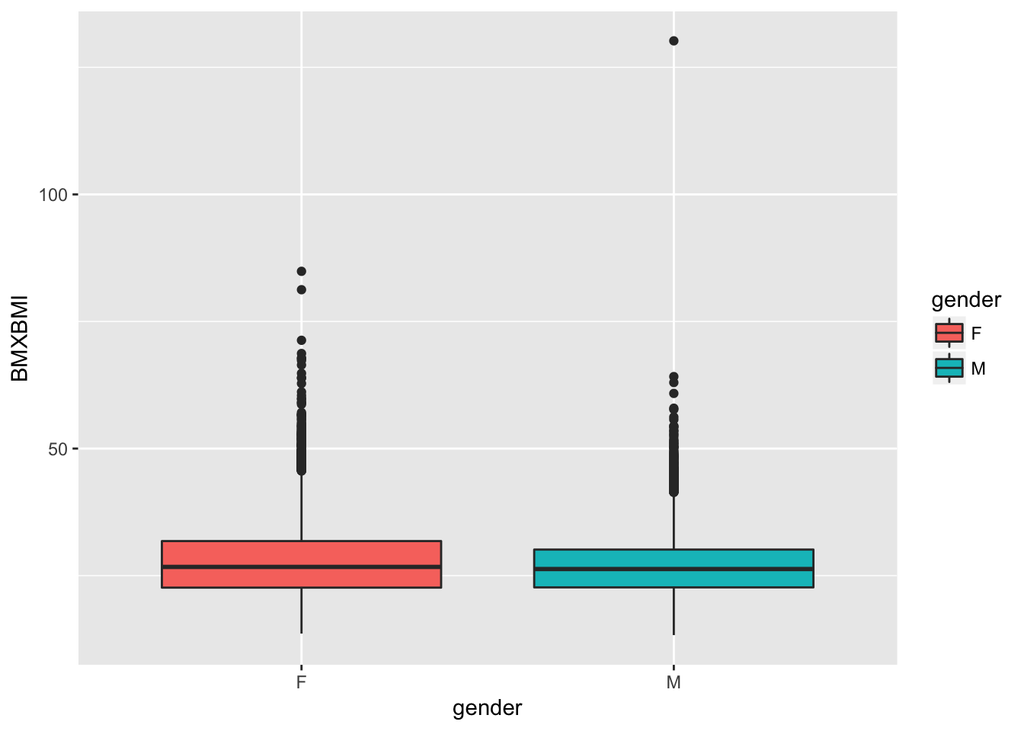

```r
ggplot(nhData, aes(x=gender, y=BMXBMI, fill=gender)) + geom_boxplot()
```

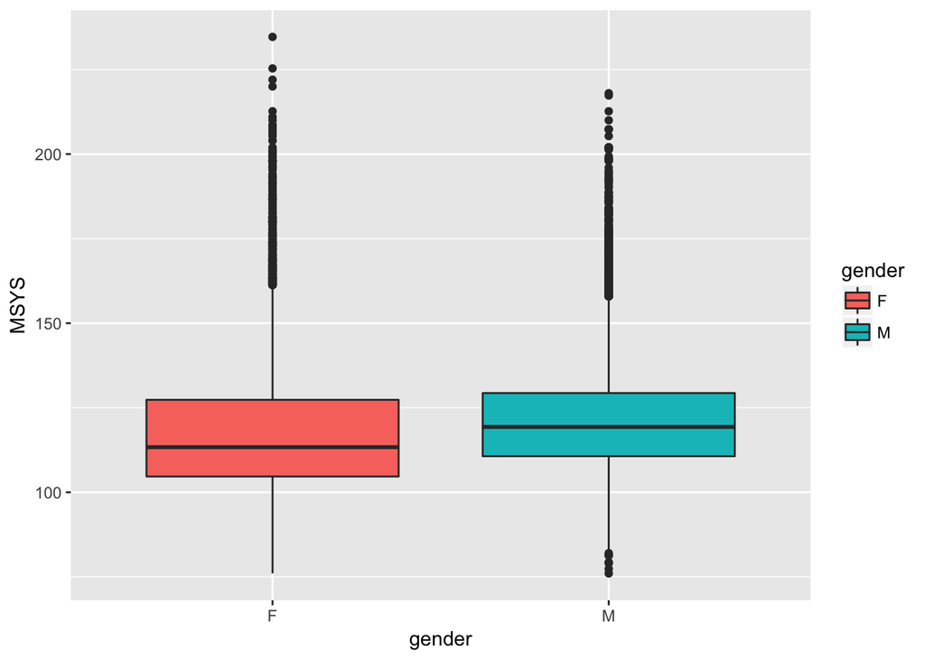

```r
ggplot(nhData, aes(x=gender, y=MSYS, fill=gender)) + geom_boxplot()
```

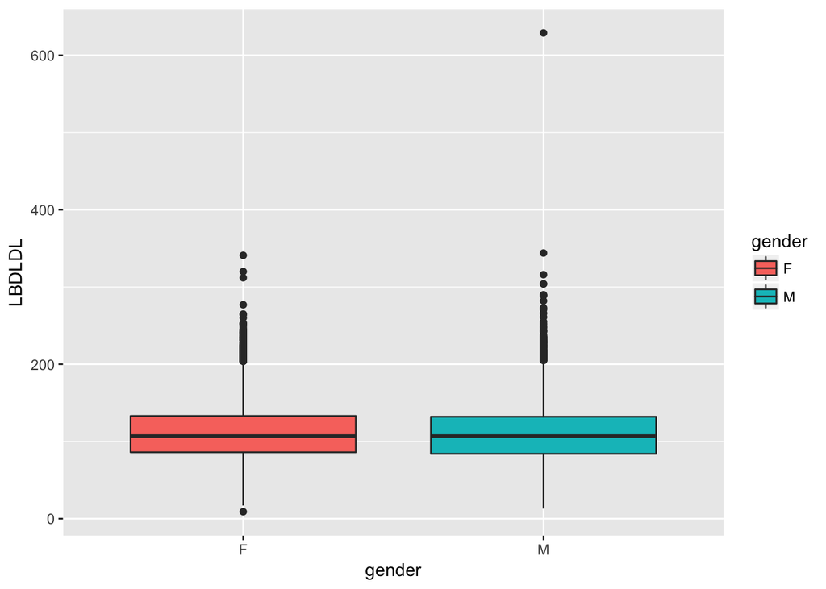

```r
ggplot(nhData, aes(x=gender, y=LBDLDL, fill=gender)) + geom_boxplot()
```

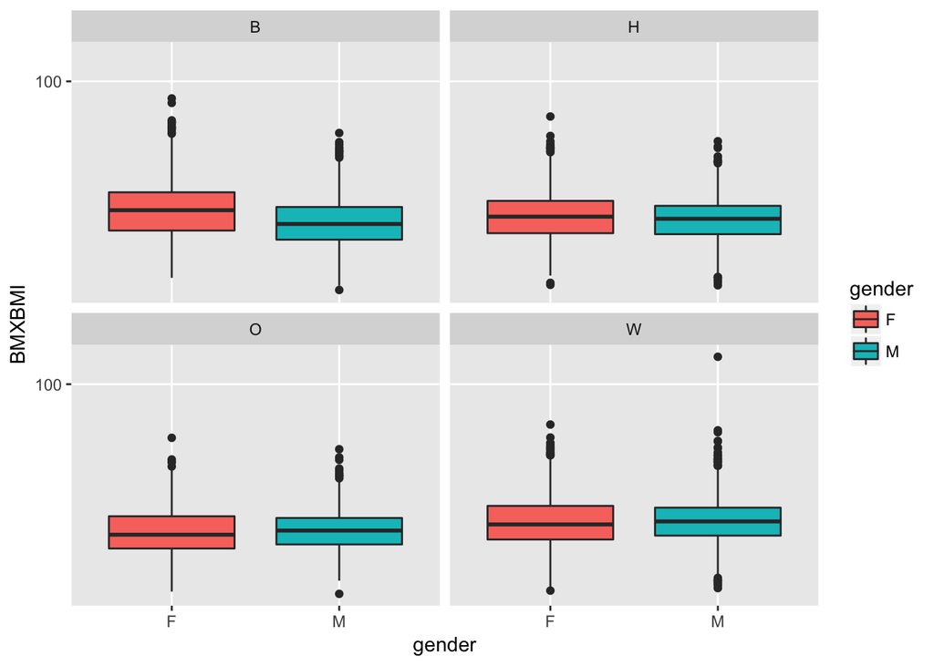

```r
ggplot(nhData, aes(x=gender, y=BMXBMI, fill=gender)) + geom_boxplot() + facet_wrap(~ethnicity) + scale_y_log10()
```

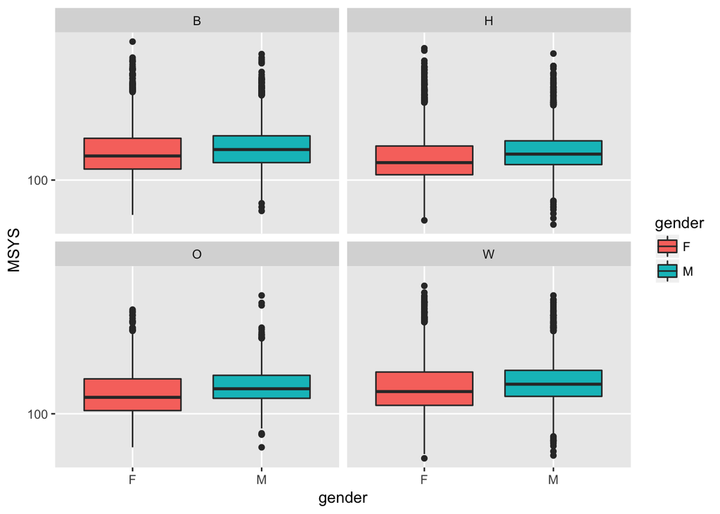

```r
ggplot(nhData, aes(x=gender, y=MSYS, fill=gender)) + geom_boxplot() + facet_wrap(~ethnicity) + scale_y_log10()
```

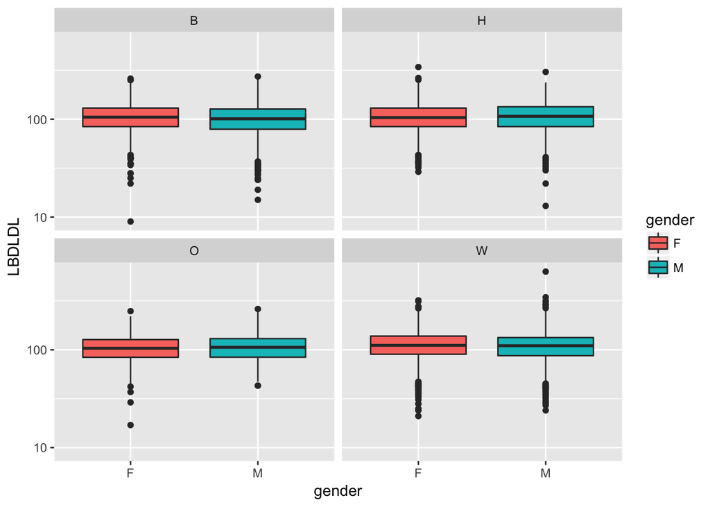

```r
ggplot(nhData, aes(x=gender, y=LBDLDL, fill=gender)) + geom_boxplot() + facet_wrap(~ethnicity) + scale_y_log10()
```

- Create a boxplot of systolic blood pressure by type 2 diabetes status facetted by gender (color by diabetes status).

http://diabetes.diabetesjournals.org/content/66/2/543

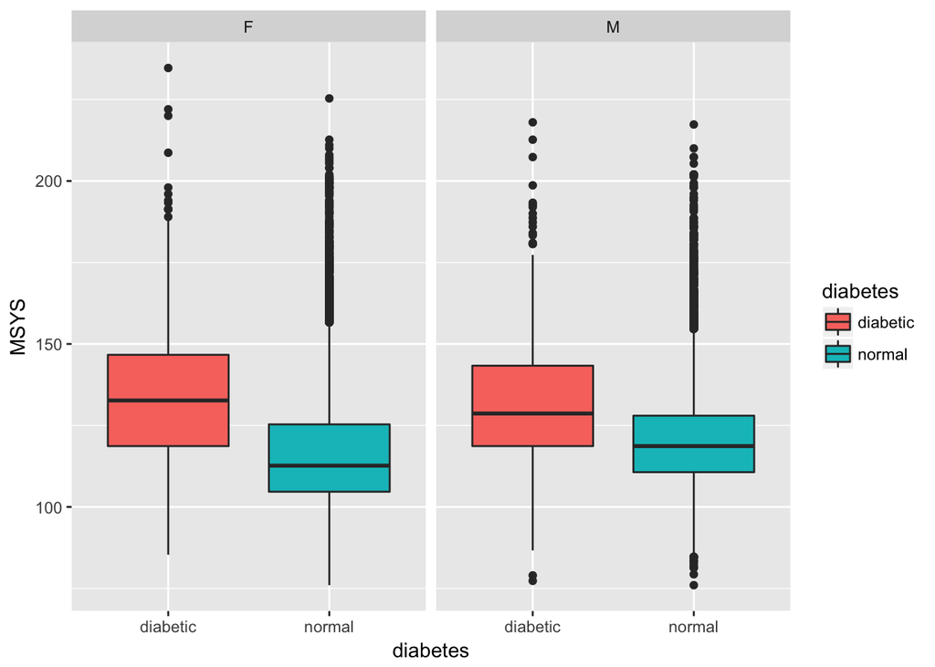

```r
ggplot(nhData, aes(x=diabetes, y=MSYS, fill=diabetes)) + geom_boxplot() + facet_wrap(~gender)
```

# Correlations

- Repeat above correlations with remaining P: glucose,HDL, LDL
- Plot the correlations in different age, sex, and race/ethnciicity groups
- Find the correlation between age and BMI

```r
nhData %>% summarise(cor(RIDAGEYR,BMXBMI))
```

```
## # A tibble: 1 x 1
##   `cor(RIDAGEYR, BMXBMI)`
##                     <dbl>
## 1               0.2395399
```

- Calculate the correlation between age and BMI and count the number of people for each gender

```r
nhData %>% group_by(gender) %>% summarise(cor(RIDAGEYR,BMXBMI), numberpeople=n())
```

```
## # A tibble: 2 x 3
##   gender `cor(RIDAGEYR, BMXBMI)` numberpeople
##    <chr>                   <dbl>        <int>
## 1      F               0.2011329         8916
## 2      M               0.2829517         8942
```

# Linear Modeling

- correlate each variable with each other
- create a linear model predicting each P as a function of age, sex, race/ethncity
- what is the R2 of each?
- what is the coeffcicients of the lienar model for each risk factor (age, sex, race/ethncitiy)? What is the interpetation?
- create a linear model predicting BMI as a function of age, sex, race/ethncity, LDL cholestrol, Triglycerides, and Systolic Blood Pressure and output the coefficients into a data frame called **fit_tidy** and the output model summary into a data frame called **fit_glance**, what is the $R^2$

```r
regressions <-  nhData %>% do(fit=lm(BMXBMI ~ RIDAGEYR+ gender+ ethnicity + LBDLDL+MSYS + LBXTR, data = .))



fit_tidy <- regressions %>% tidy(fit)

fit_glance <- regressions %>% glance(fit)

DT::datatable(fit_tidy)
```

|  | term | estimate | std.error | statistic | p.value |
| --- | --- | --- | --- | --- | --- |
| 1 | (Intercept) | 19.0952930555108 | 0.355625050357149 | 53.6950168058569 | 0 |
| 2 | RIDAGEYR | 0.0347183931601327 | 0.0027535626092071 | 12.6085359541289 | 2.70589155957518e-36 |
| 3 | genderM | -1.20265594366888 | 0.0927050343314256 | -12.9729302442122 | 2.59653859220904e-38 |
| 4 | ethnicityH | -1.41059890618375 | 0.133574551708859 | -10.5603866016209 | 5.426163221277e-26 |
| 5 | ethnicityO | -3.52925898906118 | 0.212409568402044 | -16.6153484309195 | 1.56416248567966e-61 |
| 6 | ethnicityW | -2.02831859323566 | 0.125261173954654 | -16.1927158208651 | 1.48391564230984e-58 |
| 7 | LBDLDL | 0.0127270984164125 | 0.00136541502394596 | 9.32104758861667 | 1.28309527235713e-20 |
| 8 | MSYS | 0.039997467610578 | 0.00304781676254349 | 13.1233176817359 | 3.67570943826885e-39 |
| 9 | LBXTR | 0.0237530749380416 | 0.000745752644961158 | 31.8511440737548 | 1.40762541173077e-216 |

```r
DT::datatable(fit_glance)
```

|  | r.squared | adj.r.squared | sigma | statistic | p.value | df | logLik | AIC | BIC | deviance | df.residual |
| --- | --- | --- | --- | --- | --- | --- | --- | --- | --- | --- | --- |
| 1 | 0.150166242754157 | 0.149785343540869 | 6.13566839504354 | 394.241409579529 | 0 | 9 | -57731.4406521568 | 115482.881304314 | 115560.783372974 | 671951.069346106 | 17849 |